# Майнор "Интеллектуальный анализ данных"

# Курс "Современные методы машинного обучения"

# Лабораторная работа №1. Image Classification.

Выполнил Артём Суворов, 19БИ-3, ИАД-2

Ссылка на данный колаб: [ссылка](https://colab.research.google.com/drive/110oQOdiOyhkZnjlx33uskeDG6cZ9-e26?usp=sharing)

В данной лабораторной работе вам предлагается обучить модель на основе нейронной сети для распознавания рукописных букв английского алфавита.

## Данные

```python
import torch
import torchvision
import torchvision.transforms as transforms
```

```python
from google.colab import drive
drive.mount('/content/drive', force_remount=True)
```

Данные представлены двумя датасетами: обучающим (`train`) и тестовым (`test`). Изображения для каждого датасета находятся в `images.zip`.

Обучающая выборка состоит из 65000 изображений - по 2500 изображений для каждой буквы.  
Тестовая выборка состоит из 13000 изображений - по 500 изображений для каждой буквы.

Все изображения - монохромные (но в формате RGB), размерности $28 \times 28$ пикселей, в формате JPEG. В названии каждого файла содержатся буква, которая представлена на изображении, и уникальный номер изображения: `a_00002.jpg`.

**NB:** Все изображения представлены в перевернутом виде, для корректного отображения их нужно сначала транспонировать.

```python
import numpy as np
import matplotlib.pyplot as plt
```

```python
pic = plt.imread('/content/drive/My Drive/data_science/train/a/a_00002.jpg')
print(pic.shape)
```

```
(28, 28, 3)
```

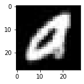

```python
plt.figure(figsize=(2,2))
plt.imshow(np.transpose(pic, axes=(1, 0, 2)))
plt.show()
```

## Основные задания

Ваша задача - создать и обучить модель на основе нейронной сети, которая будет предсказывать букву на картинке.  
Обучение необходимо проводить на данных из `train`, качество модели проверять на данных из `test`.  
Целевая метрика - accuracy.  
Для моделирования необходимо использовать `pytorch`.

### Задание 1

Вес в общей оценке - 0.35

```python
class Rotater:
    def __init__(self):
        pass


    def __call__(self, img: torch.Tensor) -> torch.Tensor:
        img = torch.rot90(img, 4, [1, 2])
        return img
```

```python
transform = transforms.Compose([
                                transforms.ToTensor(),
                                Rotater()])

train = torchvision.datasets.ImageFolder(root = '/content/drive/My Drive/data_science/train', transform=transform)
test = torchvision.datasets.ImageFolder(root = '/content/drive/My Drive/data_science/test', transform=transform)
```

```python
train_letters_loader = torch.utils.data.DataLoader(train, batch_size=4, num_workers=4, shuffle=True)
test_letters_loader = torch.utils.data.DataLoader(test, batch_size=4, num_workers=4, shuffle=True)
```

```python
dataiter = iter(train_letters_loader)
```

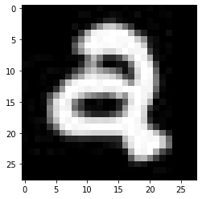

```python
images, labels = dataiter.next()

plt.imshow(images[0].permute(2, 1, 0))
```

```python
out = torchvision.utils.make_grid(images)

plt.imshow(out.permute(2, 1, 0))
```

```python
labels
```

```
tensor([ 0,  3, 12, 25])
```

Метки показывают позиции букв в алфавите

```python
alphabet = np.array(list('abcdefghijklmnopqrstuvwxyz'.upper()))

alphabet[labels]
```

```
array(['A', 'D', 'M', 'Z'], dtype='<U1')
```

1. Постройте и обучите модели с 2-мя и 3-мя полносвязными (dense) скрытыми слоями. При моделировании необходимо попробовать разные параметры нейронной сети - число нейронов на каждом слое, learning rate, batch size, функции активации, регуляризации и т.д. Оцените качество моделей с различными параметрами, проведите сравнительный анализ.

```python
device = torch.device("cuda:0" if torch.cuda.is_available() else "cpu")
```

```python
device
```

```
device(type='cpu')
```

```python
import torch.nn as nn
import torch.nn.functional as F

class Net1(nn.Module):
    def __init__(self):
        super(Net1, self).__init__()
        self.fc1 = nn.Linear(3 * 28 * 28, 600)
        self.fc2 = nn.Linear(600, 208)
        self.fc3 = nn.Linear(208, 26) # уменьшаем до числа классов
        # важно, чтобы входы и выходы совпадали


    def forward(self, x):
        # x = 28x28x3
        x = x.view(-1, 3 * 28 * 28)  # reshape
        x = F.relu(x) # non-linear activation
        x = self.fc1(x)  # передаём на полносвязные слои
        x = F.relu(x) # non-linear
        x = self.fc2(x)
        x = F.relu(x) # non-linear
        x = self.fc3(x)
        return x  # 26 значений, которые будут отвечать за класс

net1 = Net1()
```

```python
import torch.optim as optim

criterion = nn.CrossEntropyLoss()
optimizer = optim.SGD(net1.parameters(), lr=0.001, momentum=0.8)
```

```python
for epoch in range(3):  # loop over the dataset multiple times
    running_loss = 0.0
    train_cases = 0

    for i, data in enumerate(train_letters_loader, 0):
        # get the inputs; data is a list of [inputs, labels]
        inputs, labels = data
        # inputs = inputs.float()
        # labels = labels.long()

        # zero the parameter gradients
        optimizer.zero_grad()

        # forward + backward + optimize
        outputs = net1(inputs)
        # outputs = outputs.view(-1)

        # forward + backward + optimize
        loss = criterion(outputs, labels)
        loss.backward()
        optimizer.step()

        # print statistics
        running_loss += loss.item()
        train_cases += len(labels.numpy())

        if i % 500 == 499:
            # ...log the running loss
            print('[%d, %5d] loss: %.3f' %
                  (epoch + 1,
                   i + 1,
                   running_loss / train_cases))
            running_loss = 0.0

print('Finished Training')
```

```
[1,   500] loss: 0.802
[1,  1000] loss: 0.373
[1,  1500] loss: 0.203
[1,  2000] loss: 0.120
[1,  2500] loss: 0.084
[1,  3000] loss: 0.064
[1,  3500] loss: 0.050
[1,  4000] loss: 0.043
[1,  4500] loss: 0.036
[1,  5000] loss: 0.033
[1,  5500] loss: 0.028
[1,  6000] loss: 0.024
[1,  6500] loss: 0.022
[1,  7000] loss: 0.019
[1,  7500] loss: 0.017
```

[output cut: 82 more lines]

```python
# saving net1
torch.save(net1.state_dict(), '/content/drive/My Drive/data_science/net1.pth')
```

```python
# loading net1
net1 = Net1()
net1.load_state_dict(torch.load('/content/drive/My Drive/data_science/net1.pth'))
net1.eval()
```

```
Net1(
  (fc1): Linear(in_features=2352, out_features=600, bias=True)
  (fc2): Linear(in_features=600, out_features=208, bias=True)
  (fc3): Linear(in_features=208, out_features=26, bias=True)
)
```

```python
correct = 0
total = 0
with torch.no_grad():
    for data in test_letters_loader:
        images, labels = data  # получили изображения и метки
        outputs = net1(images)  # получили ответы от нейронки
        _, predicted = torch.max(outputs.data, 1)
        total += labels.size(0)
        correct += (predicted == labels).sum().item()  # считаем, сколько правильно ответили

print('Accuracy of the net1 on the 13000 test images: %d %%' % (
    100 * correct / total))
```

```
Accuracy of the net1 on the 13000 test images: 87 %
```

```python
class Net2(nn.Module):
    def __init__(self):
        super(Net2, self).__init__()
        self.fc1 = nn.Linear(3 * 28 * 28, 1200)
        self.fc2 = nn.Linear(1200, 26) # уменьшаем до числа классов


    def forward(self, x):
        # x = 28x28x3
        x = x.view(-1, 3 * 28 * 28)
        x = F.sigmoid(x)
        x = self.fc1(x)
        x = F.tanh(x)
        x = self.fc2(x)
        return x  # 26 значений, которые будут отвечать за класс

net2 = Net2()
```

```python
criterion = nn.NLLLoss()
optimizer = optim.Adam(net2.parameters(), lr=1e-4, betas=(0.99, 0.999), eps=1e-08, weight_decay=0)
```

```python
train_letters_loader2 = torch.utils.data.DataLoader(train, batch_size=10, num_workers=4, shuffle=True)
test_letters_loader2 = torch.utils.data.DataLoader(test, batch_size=10, num_workers=4, shuffle=True)
```

```python
for epoch in range(3):
    running_loss = 0.0
    train_cases = 0

    for i, data in enumerate(train_letters_loader2, 0):
        # get the inputs; data is a list of [inputs, labels]
        inputs, labels = data
        # inputs = inputs.to(torch.float64)
        # labels = labels.to(torch.float64)

        # zero the parameter gradients
        optimizer.zero_grad()

        # forward + backward + optimize
        outputs = net2(inputs)
        # outputs = outputs.view(-1)

        # forward + backward + optimize
        loss = criterion(outputs, labels)
        loss.backward()
        optimizer.step()

        # print statistics
        running_loss += loss.item()
        train_cases += len(labels.numpy())

        if i % 500 == 499:
            # ...log the running loss
            print('[%d, %5d] loss: %.3f' %
                  (epoch + 1,
                   i + 1,
                   running_loss / train_cases))
            running_loss = 0.0

print('Finished Training')
```

```
[1,   500] loss: -1.809
[1,  1000] loss: -2.547
[1,  1500] loss: -2.777
[1,  2000] loss: -2.892
[1,  2500] loss: -2.955
[1,  3000] loss: -3.000
[1,  3500] loss: -3.031
[1,  4000] loss: -3.055
[1,  4500] loss: -3.071
[1,  5000] loss: -3.086
[1,  5500] loss: -3.097
[1,  6000] loss: -3.106
[1,  6500] loss: -3.114
[2,   500] loss: -43.681
[2,  1000] loss: -23.445
```

[output cut: 24 more lines]

```python
# saving net2
torch.save(net2.state_dict(), '/content/drive/My Drive/data_science/net2.pth')
```

```python
# loading net2
net2 = Net2()
net2.load_state_dict(torch.load('/content/drive/My Drive/data_science/net2.pth'))
net2.eval()
```

```
Net2(
  (fc1): Linear(in_features=2352, out_features=1200, bias=True)
  (fc2): Linear(in_features=1200, out_features=26, bias=True)
)
```

```python
correct = 0
total = 0
with torch.no_grad():
    for data in test_letters_loader2:
        images, labels = data  # получили изображения и метки
        outputs = net2(images)  # получили ответы от нейронки
        _, predicted = torch.max(outputs.data, 1)
        total += labels.size(0)
        correct += (predicted == labels).sum().item()  # считаем, сколько правильно ответили

print('Accuracy of the net2 on the 13000 test images: %d %%' % (
    100 * correct / total))
```

```
Accuracy of the net2 on the 13000 test images: 3 %
```

Получили такие результаты:

- качество net1: 87%
- качество net2: 3%

Очевидно, что лучшей моделью является первая модель

```python
predicted1 = np.array([])
target1 = np.array([])
outputs1 = np.empty(26)

all_images = []

with torch.no_grad():
    for data in test_letters_loader:
        images, labels = data  # получили изображения и метки
        outputs = net1(images)  # получили ответы от нейронки
        _, prediction = torch.max(outputs.data, 1)

        predicted1 = np.append(predicted1, prediction.data)
        target1 = np.append(target1, labels.data)

        for output in outputs:
            outputs1 = np.vstack([outputs1, output.numpy()])

        all_images.extend(images.numpy())  # понадобится для вывода изображений, которые неправильно распознаны

predicted1 = torch.tensor(predicted1).to(torch.int32)
target1 = torch.tensor(target1).to(torch.int32)
outputs1 = torch.tensor(outputs1)
```

```python
predicted2 = np.array([])
target2 = np.array([])
outputs2 = np.empty(26)
with torch.no_grad():
    for data in test_letters_loader2:
        images, labels = data  # получили изображения и метки
        outputs = net2(images)  # получили ответы от нейронки
        _, prediction = torch.max(outputs.data, 1)

        predicted2 = np.append(predicted2, prediction.data)
        target2 = np.append(target2, labels.data)

        for output in outputs:
            outputs2 = np.vstack([outputs2, output.numpy()])

predicted2 = torch.tensor(predicted2).to(torch.int32)
target2 = torch.tensor(target2).to(torch.int32)
outputs2 = torch.tensor(outputs2)
```

```python
!pip install torchmetrics
```

```python
from torchmetrics import Accuracy, AUROC, AveragePrecision

accuracy = Accuracy()
print('Accuracy: ')
print('net1:', accuracy(predicted1, target1))
print('net2:', accuracy(predicted2, target2))
print()

auroc = AUROC(num_classes=26)
print('ROC AUC:')
print('net1:', auroc(outputs1[1:], target1))
print('net2:', auroc(outputs2[1:], target2))
print()

average_precision = AveragePrecision(num_classes=26, average=None)
print('Average Precision:')
print('net1:', average_precision(outputs1[1:], target1))
print('net2:', average_precision(outputs2[1:], target2))
print()
```

```
Accuracy:
net1: tensor(0.8742)
net2: tensor(0.0385)

ROC AUC:
net1: tensor(0.9803)
```

```
net2: tensor(0.5000)

Average Precision:
net1: [tensor(0.6048), tensor(0.7279), tensor(0.8882), tensor(0.7487), tensor(0.7995), tensor(0.8509), tensor(0.4670), tensor(0.8435), tensor(0.2695), tensor(0.8080), tensor(0.8084), tensor(0.6057), tensor(0.9298), tensor(0.7662), tensor(0.9063), tensor(0.8853), tensor(0.6063), tensor(0.7718), tenso…
net2: [tensor(0.0385), tensor(0.0385), tensor(0.0385), tensor(0.0385), tensor(0.0385), tensor(0.0385), tensor(0.0385), tensor(0.0385), tensor(0.0385), tensor(0.0385), tensor(0.0385), tensor(0.0385), tensor(0.0385), tensor(0.0385), tensor(0.0385), tensor(0.0385), tensor(0.0385), tensor(0.0385), tenso…
```

По всем параметрам net1 получилась лучше

1. Для наилучшей модели постройте confusion matrix результатов предсказаний модели на тестовых данных. Насколько равномерно обучилась ваша модель? Приведите буквы с самой лучшей и с самой худшей точностью детекции.

```python
from torchmetrics import ConfusionMatrix
import seaborn as sns

confmat = ConfusionMatrix(num_classes=26)

confmat1 = confmat(predicted1, target1)
confmat2 = confmat(predicted2, target2)
```

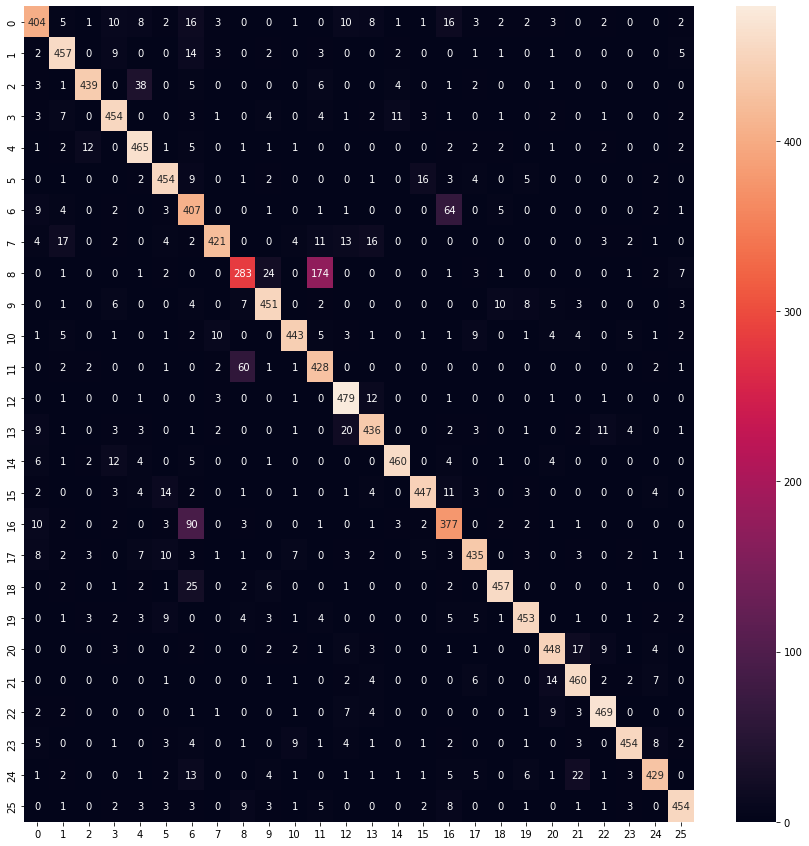

```python
plt.figure(figsize=(15, 15))
sns.heatmap(confmat1.to(torch.int32), annot=True, fmt='d')
```

В целом, модель обучилась довольно равномерно, но есть просадки в паре букв

```python
alphabet[22], alphabet[6]
```

```
('W', 'G')
```

1. Найдите 10 пар букв, которые чаще всего путаются между собой, дайте возможное объяснение. Приведите примеры с картинками, которые были детектированы с ошибкой.

```python
misunderstood_letters = {}

for i in range(confmat1.size()[0]):
    for j in range(confmat1.size()[1]):
        if i != j:
            misunderstood_letters[(alphabet[i], alphabet[j])] = confmat1[i][j].item()

sorted(misunderstood_letters.items(), key=lambda x: x[1], reverse=True)[:10]
```

```
[(('I', 'L'), 174.0),
 (('Q', 'G'), 90.0),
 (('G', 'Q'), 64.0),
 (('L', 'I'), 60.0),
 (('C', 'E'), 38.0),
 (('S', 'G'), 25.0),
 (('I', 'J'), 24.0),
 (('Y', 'V'), 22.0),
 (('N', 'M'), 20.0),
 (('H', 'B'), 17.0)]
```

Многие буквы могут перепутать и люди - настолько они похожи. Например, I от l отличить довольно сложно (I и L)

```python
indexes_of_misunderstood = []
match_answers = torch.tensor(predicted1 == target1)

for i in range(match_answers.size()[0]):
    if not match_answers[i]:
        indexes_of_misunderstood.append(i)
```

```python
print(match_answers.shape)
print(indexes_of_misunderstood)
```

```
torch.Size([13000])
[4, 16, 48, 53, 55, 56, 72, 83, 103, 111, 121, 125, 137, 141, 142, 146, 149, 170, 186, 189, 196, 198, 209, 213, 216, 219, 236, 238, 240, 247, 251, 268, 279, 281, 295, 301, 302, 306, 314, 315, 316, 321, 340, 349, 350, 358, 362, 370, 380, 384, 398, 405, 409, 422, 435, 445, 449, 453, 455, 463, 465, 480…
```

```python
some_indexes = indexes_of_misunderstood[:5]  # индексы 5 букв, которые были неправильно распознаны
print(some_indexes)
```

```
[4, 16, 48, 53, 55]
```

```python
all_images = torch.tensor(all_images)
all_images.shape
```

```
torch.Size([13000, 3, 28, 28])
```

```python
corresponding_images = all_images[some_indexes]
corresponding_images.shape
```

```
torch.Size([5, 3, 28, 28])
```

```python
out = torchvision.utils.make_grid(corresponding_images)

plt.imshow(out.permute(2, 1, 0))
```

[output not shown]

По мнению net1 это следующие буквы:

```python
np.array(alphabet)[predicted1[some_indexes]]
```

```
array(['D', 'Q', 'H', 'V', 'E'], dtype='<U1')
```

1. Возьмите первую букву вашей фамилии и укажите её точность детекции. С какими буквами ваша модель чаще всего путает эту букву?

```python
class_correct = list(0. for i in range(26))
class_total = list(0. for i in range(26))

classes = list(alphabet[i] for i in range(26))

# тут определяем корректность для каждого класса

with torch.no_grad():
    for data in test_letters_loader:
        images, labels = data
        outputs = net1(images)
        _, predicted = torch.max(outputs, 1)
        c = (predicted == labels).squeeze()
        for i in range(4):
            try:
                label = labels[i].int().numpy()
                class_correct[label] += c[i].item()
                class_total[label] += 1
            except IndexError:
                continue

for i in range(26):
    try:
        print('Accuracy of %5s : %2d %%' % (
        classes[i], 100 * class_correct[i] / class_total[i]))
    except ZeroDivisionError:
        print('Class was skipped')
```

```
Accuracy of     A : 80 %
Accuracy of     B : 91 %
Accuracy of     C : 87 %
Accuracy of     D : 90 %
Accuracy of     E : 93 %
Accuracy of     F : 90 %
Accuracy of     G : 81 %
Accuracy of     H : 84 %
Accuracy of     I : 56 %
Accuracy of     J : 90 %
Accuracy of     K : 88 %
Accuracy of     L : 85 %
Accuracy of     M : 95 %
Accuracy of     N : 87 %
Accuracy of     O : 92 %
Accuracy of     P : 89 %
Accuracy of     Q : 75 %
Accuracy of     R : 87 %
Accuracy of     S : 91 %
Accuracy of     T : 90 %
Accuracy of     U : 89 %
Accuracy of     V : 92 %
Accuracy of     W : 93 %
Accuracy of     X : 90 %
Accuracy of     Y : 85 %
Accuracy of     Z : 90 %
```

На английском первая буква моей фамилии - S. Точность распознавания этой буквы - 91%

```python
incorrect_letters = list(0. for i in range(26))

with torch.no_grad():
    for data in test_letters_loader:
        images, labels = data
        outputs = net1(images)
        _, predicted = torch.max(outputs, 1)
        for i in range(len(labels)):
            label = labels[i].int().numpy()
            pred = predicted[i].int().numpy()

            if alphabet[pred] == 'S' and alphabet[label] != 'S':
                incorrect_letters[label] += 1
```

```python
sorted(zip(alphabet, incorrect_letters), key=lambda x: x[1], reverse=True)[:5]
```

```
[('J', 10.0), ('G', 5.0), ('A', 2.0), ('E', 2.0), ('Q', 2.0)]
```

Как можно видеть, чаще всего модель путает S с G, J и A

### Задание 2

*Вес в общей оценке - 0.35*

1. Постройте и обучите модели нейронной сети с 1-м, 2-мя и 3-мя сверточными слоями.  
   Попробуйте различные значения параметров сверток и числа фильтров на каждом слое. Оцените качество моделей с различными параметрами, проведите сравнительный анализ.
2. Для наилучшей конфигурации из предыдущего пункта, сравните, как меняется качество модели при увеличении размера батча при использовании BatchNorm и GroupNorm.

```python
class NetConv1(nn.Module):
    def __init__(self):
        super(NetConv1, self).__init__()
        self.conv1 = nn.Conv2d(3, 6, 21)

        self.fc1 = nn.Linear(6 * 8 * 8, 100)
        self.fc2 = nn.Linear(100, 26)


    def forward(self, x):
        # x = 28x28x3
        x = self.conv1(x) # 8x8x6
        x = F.relu(x)
        x = x.view(-1, 6 * 8 * 8)
        x = F.relu(x)
        x = self.fc1(x)
        x = F.relu(x)
        x = self.fc2(x)
        x = F.softmax(x, dim=1)
        return x

netConv1 = NetConv1()
```

```python
class NetConv2(nn.Module):
    def __init__(self):
        super(NetConv2, self).__init__()
        self.conv1 = nn.Conv2d(3, 16, 11)
        self.conv2 = nn.Conv2d(16, 32, 11)

        self.fc1 = nn.Linear(32 * 8 * 8, 600)
        self.fc2 = nn.Linear(600, 100)
        self.fc3 = nn.Linear(100, 26)


    def forward(self, x):
        # x = 28x28x3
        x = self.conv1(x) # 18x18x16
        x = F.relu(x)
        x = self.conv2(x) # 8x8x32
        x = x.view(-1, 32 * 8 * 8)
        x = F.relu(x)
        x = self.fc1(x)
        x = F.relu(x)
        x = self.fc2(x)
        x = F.relu(x)
        x = self.fc3(x)
        x = F.softmax(x, dim=1)
        return x

netConv2 = NetConv2()
```

```python
class NetConv3(nn.Module):
    def __init__(self):
        super(NetConv3, self).__init__()
        self.conv1 = nn.Conv2d(3, 6, 7)
        self.conv2 = nn.Conv2d(6, 12, 6)
        self.conv3 = nn.Conv2d(12, 18, 5)

        self.fc1 = nn.Linear(18 * 13 * 13, 1500)
        self.fc2 = nn.Linear(1500, 600)
        self.fc3 = nn.Linear(600, 208)
        self.fc4 = nn.Linear(208, 26)


    def forward(self, x):
        # x = 28x28x3
        x = self.conv1(x)  # 22x22x6
        x = F.relu(x)
        x = self.conv2(x)  # 17x17x12
        x = F.relu(x)
        x = self.conv3(x)  # 13x13x18
        x = x.view(-1, 18 * 13 * 13)
        x = F.relu(x)
        x = self.fc1(x)
        x = F.relu(x)
        x = self.fc2(x)
        x = F.relu(x)
        x = self.fc3(x)
        x = F.relu(x)
        x = self.fc4(x)
        x = F.softmax(x)
        return x

netConv3 = NetConv3()
```

```python
nets = [netConv1, netConv2, netConv3]
```

```python
train_letters_loaderConv = torch.utils.data.DataLoader(train, batch_size=10, num_workers=4, shuffle=True)
test_letters_loaderConv = torch.utils.data.DataLoader(test, batch_size=10, num_workers=4, shuffle=True)
```

```python
for net in nets:

    criterion = nn.CrossEntropyLoss()
    optimizer = optim.Adam(net.parameters(), lr=1e-4, betas=(0.99, 0.999), eps=1e-08, weight_decay=0)

    for epoch in range(4):  # loop over the dataset multiple times
        running_loss = 0.0
        train_cases = 0

        for i, data in enumerate(train_letters_loaderConv, 0):
            # get the inputs; data is a list of [inputs, labels]
            inputs, labels = data
            # inputs = inputs.float()
            # labels = labels.long()

            # zero the parameter gradients
            optimizer.zero_grad()

            # forward + backward + optimize
            outputs = net(inputs)
            # outputs = outputs.view(-1)

            # forward + backward + optimize
            loss = criterion(outputs, labels)
            loss.backward()
            optimizer.step()

            # print statistics
            running_loss += loss.item()
            train_cases += len(labels.numpy()
            )
            if i % 500 == 499:
                # ...log the running loss
                print('[%d, %5d] loss: %.3f' %
                    (epoch + 1,
                     i + 1,
                     running_loss / train_cases))
                running_loss = 0.0

    print('Finished Training')
```

```
[1,   500] loss: 0.321
[1,  1000] loss: 0.154
[1,  1500] loss: 0.100
[1,  2000] loss: 0.074
[1,  2500] loss: 0.058
[1,  3000] loss: 0.048
[1,  3500] loss: 0.041
[1,  4000] loss: 0.036
[1,  4500] loss: 0.032
[1,  5000] loss: 0.029
[1,  5500] loss: 0.026
[1,  6000] loss: 0.024
[1,  6500] loss: 0.022
[2,   500] loss: 0.283
[2,  1000] loss: 0.142
```

[output cut: 91 more lines]

```
[1,   500] loss: 0.319
[1,  1000] loss: 0.158
[1,  1500] loss: 0.104
[1,  2000] loss: 0.075
[1,  2500] loss: 0.059
[1,  3000] loss: 0.048
[1,  3500] loss: 0.040
[1,  4000] loss: 0.035
[1,  4500] loss: 0.031
[1,  5000] loss: 0.028
[1,  5500] loss: 0.025
[1,  6000] loss: 0.022
[1,  6500] loss: 0.021
[2,   500] loss: 0.267
[2,  1000] loss: 0.133
```

[output cut: 38 more lines]

```python
# saving nets
for i in range(len(nets)):
    torch.save(nets[i].state_dict(), f'/content/drive/My Drive/data_science/netConv{i + 1}.pth')
```

```python
# loading nets
netConv1 = NetConv1()
netConv1.load_state_dict(torch.load('/content/drive/My Drive/data_science/netConv1.pth'))
netConv1.eval()

netConv2 = NetConv2()
netConv2.load_state_dict(torch.load('/content/drive/My Drive/data_science/netConv2.pth'))
netConv2.eval()

netConv3 = NetConv3()
netConv3.load_state_dict(torch.load('/content/drive/My Drive/data_science/netConv3.pth'))
netConv3.eval()

nets = [netConv1, netConv2, netConv3]
```

```python
predictedConv = [np.array([])] * 3
targetConv = [np.array([])] * 3
outputsConv = [np.empty(26)] * 3

for i in range(len(nets)):
    with torch.no_grad():
        for data in test_letters_loaderConv:
            images, labels = data
            outputs = nets[i](images)  # получили ответы от нейронки
            _, prediction = torch.max(outputs.data, 1)

            predictedConv[i] = np.append(predictedConv[i], prediction.data)
            targetConv[i] = np.append(targetConv[i], labels.data)

            for output in outputs:
                outputsConv[i] = np.vstack([outputsConv[i], output.numpy()])

    predictedConv[i] = torch.tensor(predictedConv[i]).to(torch.int32)
    targetConv[i] = torch.tensor(targetConv[i]).to(torch.int32)
    outputsConv[i] = torch.tensor(outputsConv[i])
```

```python
accuracy = Accuracy()
print('Accuracy: ')
for i in range(len(nets)):
    print(f'netConv{i + 1}:', accuracy(predictedConv[i], targetConv[i]))
print()

auroc = AUROC(num_classes=26)
print('ROC AUC:')

for i in range(len(nets)):
    print(f'netConv{i + 1}:', auroc(outputsConv[i][1:], targetConv[i]))
print()

average_precision = AveragePrecision(num_classes=26, average=None)
print('Average Precision:')
for i in range(len(nets)):
    print(f'netConv{i + 1}:', average_precision(outputsConv[i][1:], targetConv[i]))
print()
```

```
Accuracy:
netConv1: tensor(0.6075)
netConv2: tensor(0.7433)
netConv3: tensor(0.8229)

ROC AUC:
netConv1: tensor(0.8849)
```

```
netConv2: tensor(0.9422)
netConv3: tensor(0.9716)

Average Precision:
netConv1: [tensor(0.0421), tensor(0.7248), tensor(0.8794), tensor(0.6482), tensor(0.7784), tensor(0.8468), tensor(0.0439), tensor(0.0831), tensor(0.5919), tensor(0.8699), tensor(0.0509), tensor(0.5923), tensor(0.9064), tensor(0.0688), tensor(0.0359), tensor(0.8796), tensor(0.5310), tensor(0.6807), t…
```

```
netConv2: [tensor(0.0430), tensor(0.8656), tensor(0.9628), tensor(0.9220), tensor(0.9435), tensor(0.9581), tensor(0.0610), tensor(0.0693), tensor(0.6772), tensor(0.9362), tensor(0.7795), tensor(0.7320), tensor(0.9541), tensor(0.8735), tensor(0.9552), tensor(0.9439), tensor(0.6451), tensor(0.7466), t…
netConv3: [tensor(0.8182), tensor(0.9240), tensor(0.9611), tensor(0.7283), tensor(0.9222), tensor(0.9605), tensor(0.6122), tensor(0.9448), tensor(0.4745), tensor(0.8783), tensor(0.9412), tensor(0.7186), tensor(0.9501), tensor(0.9196), tensor(0.8055), tensor(0.9593), tensor(0.0711), tensor(0.7892), t…
```

Все модели обучились довольно хорошо. Но попробуем применить BatchNorm

```python
class NetConvBN1(nn.Module):
    def __init__(self):
        super(NetConvBN1, self).__init__()
        self.conv1 = nn.Conv2d(3, 6, 21)
        self.conv1_bn = nn.BatchNorm2d(6)

        self.fc1 = nn.Linear(6 * 8 * 8, 100)
        self.fc1_bn = nn.BatchNorm1d(100)

        self.fc2 = nn.Linear(100, 26)


    def forward(self, x):
        # x = 28x28x3
        x = self.conv1(x) # 8x8x6
        x = F.relu(self.conv1_bn(x))
        x = x.view(-1, 6 * 8 * 8)
        x = F.relu(x)
        x = self.fc1(x)
        x = F.relu(self.fc1_bn(x))
        x = self.fc2(x)
        x = F.softmax(x, dim=1)
        return x

netConvBN1 = NetConvBN1()
```

```python
class NetConvBN2(nn.Module):
    def __init__(self):
        super(NetConvBN2, self).__init__()
        self.conv1 = nn.Conv2d(3, 16, 11)
        self.conv1_bn = nn.BatchNorm2d(16)

        self.conv2 = nn.Conv2d(16, 32, 11)
        self.conv2_bn = nn.BatchNorm2d(32)

        self.fc1 = nn.Linear(32 * 8 * 8, 600)
        self.fc1_bn = nn.BatchNorm1d(600)

        self.fc2 = nn.Linear(600, 100)
        self.fc2_bn = nn.BatchNorm1d(100)

        self.fc3 = nn.Linear(100, 26)


    def forward(self, x):
        # x = 28x28x3
        x = self.conv1(x) # 18x18x16
        x = F.relu(self.conv1_bn(x))
        x = self.conv2(x) # 8x8x32
        x = x.view(-1, 32 * 8 * 8)
        x = F.relu(x)
        x = self.fc1(x)
        x = F.relu(self.fc1_bn(x))
        x = self.fc2(x)
        x = F.relu(self.fc2_bn(x))
        x = self.fc3(x)
        x = F.softmax(x, dim=1)
        return x

netConvBN2 = NetConvBN2()
```

```python
class NetConvBN3(nn.Module):
    def __init__(self):
        super(NetConvBN3, self).__init__()
        self.conv1 = nn.Conv2d(3, 6, 7)
        self.conv1_bn = nn.BatchNorm2d(6)

        self.conv2 = nn.Conv2d(6, 12, 6)
        self.conv2_bn = nn.BatchNorm2d(12)

        self.conv3 = nn.Conv2d(12, 18, 5)
        self.conv3_bn = nn.BatchNorm2d(18)

        self.fc1 = nn.Linear(18 * 13 * 13, 1500)
        self.fc1_bn = nn.BatchNorm1d(1500)

        self.fc2 = nn.Linear(1500, 600)
        self.fc2_bn = nn.BatchNorm1d(600)

        self.fc3 = nn.Linear(600, 208)
        self.fc3_bn = nn.BatchNorm1d(208)

        self.fc4 = nn.Linear(208, 26)


    def forward(self, x):
        # x = 28x28x3
        x = self.conv1(x)  # 22x22x6
        x = F.relu(self.conv1_bn(x))
        x = self.conv2(x)  # 17x17x12
        x = F.relu(self.conv2_bn(x))
        x = self.conv3(x)  # 13x13x18
        x = F.relu(self.conv3_bn(x))
        x = x.view(-1, 18 * 13 * 13)
        x = F.relu(x)
        x = self.fc1(x)
        x = F.relu(self.fc1_bn(x))
        x = self.fc2(x)
        x = F.relu(self.fc2_bn(x))
        x = self.fc3(x)
        x = F.relu(self.fc3_bn(x))
        x = self.fc4(x)
        x = F.softmax(x)
        return x

netConvBN3 = NetConvBN3()
```

```python
netsBN = [netConvBN1, netConvBN2, netConvBN3]
```

```python
for net in netsBN:

    criterion = nn.CrossEntropyLoss()
    optimizer = optim.Adam(net.parameters(), lr=1e-4, betas=(0.99, 0.999), eps=1e-08, weight_decay=0)

    for epoch in range(4):  # loop over the dataset multiple times
        running_loss = 0.0
        train_cases = 0

        for i, data in enumerate(train_letters_loaderConv, 0):
            # get the inputs; data is a list of [inputs, labels]
            inputs, labels = data
            # inputs = inputs.float()
            # labels = labels.long()

            # zero the parameter gradients
            optimizer.zero_grad()

            # forward + backward + optimize
            outputs = net(inputs)
            # outputs = outputs.view(-1)

            # forward + backward + optimize
            loss = criterion(outputs, labels)
            loss.backward()
            optimizer.step()

            # print statistics
            running_loss += loss.item()
            train_cases += len(labels.numpy())

            if i % 500 == 499:
                # ...log the running loss
                print('[%d, %5d] loss: %.3f' %
                    (epoch + 1,
                     i + 1,
                     running_loss / train_cases))
                running_loss = 0.0

    print('Finished Training')
```

```
[1,   500] loss: 0.320
[1,  1000] loss: 0.156
[1,  1500] loss: 0.102
[1,  2000] loss: 0.075
[1,  2500] loss: 0.060
[1,  3000] loss: 0.049
[1,  3500] loss: 0.042
[1,  4000] loss: 0.036
[1,  4500] loss: 0.032
[1,  5000] loss: 0.029
[1,  5500] loss: 0.026
[1,  6000] loss: 0.024
[1,  6500] loss: 0.022
[2,   500] loss: 0.279
[2,  1000] loss: 0.139
```

[output cut: 91 more lines]

```
[1,   500] loss: 0.307
[1,  1000] loss: 0.142
[1,  1500] loss: 0.091
[1,  2000] loss: 0.067
[1,  2500] loss: 0.053
[1,  3000] loss: 0.044
[1,  3500] loss: 0.037
[1,  4000] loss: 0.032
[1,  4500] loss: 0.029
[1,  5000] loss: 0.026
[1,  5500] loss: 0.023
[1,  6000] loss: 0.021
[1,  6500] loss: 0.020
[2,   500] loss: 0.251
[2,  1000] loss: 0.125
```

[output cut: 38 more lines]

```python
# saving nets
for i in range(len(netsBN)):
    torch.save(netsBN[i].state_dict(), f'/content/drive/My Drive/data_science/netConvBN{i + 1}.pth')
```

```python
# loading nets
netConvBN1 = NetConvBN1()
netConvBN1.load_state_dict(torch.load('/content/drive/My Drive/data_science/netConvBN1.pth'))
netConvBN1.eval()

netConvBN2 = NetConvBN2()
netConvBN2.load_state_dict(torch.load('/content/drive/My Drive/data_science/netConvBN2.pth'))
netConvBN2.eval()

netConvBN3 = NetConvBN3()
netConvBN3.load_state_dict(torch.load('/content/drive/My Drive/data_science/netConvBN3.pth'))
netConvBN3.eval()

netsBN = [netConvBN1, netConvBN2, netConvBN3]
```

```python
predictedConvBN = [np.array([])] * 3
targetConvBN = [np.array([])] * 3
outputsConvBN = [np.empty(26)] * 3

for i in range(len(netsBN)):
    with torch.no_grad():
        for data in test_letters_loaderConv:
            images, labels = data
            outputs = netsBN[i](images)
            _, prediction = torch.max(outputs.data, 1)

            predictedConvBN[i] = np.append(predictedConvBN[i], prediction.data)
            targetConvBN[i] = np.append(targetConvBN[i], labels.data)

            for output in outputs:
                outputsConvBN[i] = np.vstack([outputsConvBN[i], output.numpy()])

    predictedConvBN[i] = torch.tensor(predictedConvBN[i]).to(torch.int32)
    targetConvBN[i] = torch.tensor(targetConvBN[i]).to(torch.int32)
    outputsConvBN[i] = torch.tensor(outputsConvBN[i])
```

```python
accuracy = Accuracy()
print('Accuracy: ')
for i in range(len(nets)):
    print(f'netConvBN{i + 1}:', accuracy(predictedConvBN[i], targetConvBN[i]))
print()

auroc = AUROC(num_classes=26)
print('ROC AUC:')

for i in range(len(nets)):
    print(f'netConvBN{i + 1}:', auroc(outputsConvBN[i][1:], targetConvBN[i]))
print()

average_precision = AveragePrecision(num_classes=26, average=None)
print('Average Precision:')
for i in range(len(nets)):
    print(f'netConvBN{i + 1}:', average_precision(outputsConvBN[i][1:], targetConvBN[i]))
print()
```

```
Accuracy:
netConvBN1: tensor(0.7507)
netConvBN2: tensor(0.9123)
netConvBN3: tensor(0.9134)

ROC AUC:
netConvBN1: tensor(0.9774)
```

```
netConvBN2: tensor(0.9946)
netConvBN3: tensor(0.9948)

Average Precision:
netConvBN1: [tensor(0.6417), tensor(0.8774), tensor(0.9120), tensor(0.8237), tensor(0.9023), tensor(0.8714), tensor(0.6974), tensor(0.8446), tensor(0.6298), tensor(0.9013), tensor(0.7973), tensor(0.2055), tensor(0.9608), tensor(0.8391), tensor(0.9447), tensor(0.9217), tensor(0.5043), tensor(0.7269),…
netConvBN2: [tensor(0.9453), tensor(0.9868), tensor(0.9878), tensor(0.9610), tensor(0.9814), tensor(0.9798), tensor(0.8811), tensor(0.9811), tensor(0.7129), tensor(0.9607), tensor(0.9883), tensor(0.7006), tensor(0.9911), tensor(0.9667), tensor(0.9863), tensor(0.9843), tensor(0.8807), tensor(0.9800),…
netConvBN3: [tensor(0.9551), tensor(0.9879), tensor(0.9916), tensor(0.9696), tensor(0.9834), tensor(0.9805), tensor(0.8678), tensor(0.9747), tensor(0.6774), tensor(0.9584), tensor(0.9911), tensor(0.7206), tensor(0.9940), tensor(0.9724), tensor(0.9898), tensor(0.9841), tensor(0.8876), tensor(0.9769),…
```

### Задание 3

Обучите модель с точностью (accuracy) на тестовых данных:

- `>= 0.85` +1 балл
- `>= 0.95` +2 балла
- `>= 0.99` +3 балла

Следующая модель обучилась с точностью 0.91

```python
netConvBN3
```

```
NetConvBN3(
  (conv1): Conv2d(3, 6, kernel_size=(7, 7), stride=(1, 1))
  (conv1_bn): BatchNorm2d(6, eps=1e-05, momentum=0.1, affine=True, track_running_stats=True)
  (conv2): Conv2d(6, 12, kernel_size=(6, 6), stride=(1, 1))
  (conv2_bn): BatchNorm2d(12, eps=1e-05, momentum=0.1, affine=True, track_running_stats=True)
  (conv3): Conv2d(12, 18, kernel_size=(5, 5), stride=(1, 1))
  (conv3_bn): BatchNorm2d(18, eps=1e-05, momentum=0.1, affine=True, track_running_stats=True)
  (fc1): Linear(in_features=3042, out_features=1500, bias=True)
  (fc1_bn): BatchNorm1d(1500, eps=1e-05, momentum=0.1, affine=True, track_running_stats=True)
  (fc2): Linear(in_features=1500, out_features=600, bias=True)
  (fc2_bn): BatchNorm1d(600, eps=1e-05, momentum=0.1, affine=True, track_running_stats=True)
  (fc3): Linear(in_features=600, out_features=208, bias=True)
  (fc3_bn): BatchNorm1d(208, eps=1e-05, momentum=0.1, affine=True, track_running_stats=True)
  (fc4): Linear(in_features=208, out_features=26, bias=True)
)
```

## Бонусные задания

**Задание 1 (1 балл).**

Напишите на листке белой бумаги (маркером или ручкой) от 5 разных букв (можно больше 5 букв в целом с повторениями, но должно быть минимум 5 разных) английского алфавита (в датасете есть как прописные, так и строчные буквы). Сфотографируйте букву и приведите её картинку к размеру $28\times28$ и, желательно, к чёрно-белой палитре цветов. Передайте получившиеся изображения вашей модели и выполните предсказание, оцените результат.

**Tips:**

- В датасете все буквы занимают практически всё пространство картинки по высоте или ширине (или вместе). Если ваша буква будет слишком маленькой или большой, это может повлиять на результат детекции.
- Помните, что буква должна быть белого цвета, а фон - чёрного.
- Описание ваших действий при выполнении этого задания (что вы использовали, чтобы привести картинку к нужному виду) категорически приветствуется :)

Будем проверять на следующих буквах:

```python
written_alphabet = np.array(list('forsuw'.upper()))
```

### От руки

Написанная от руки надпись выглядит так:

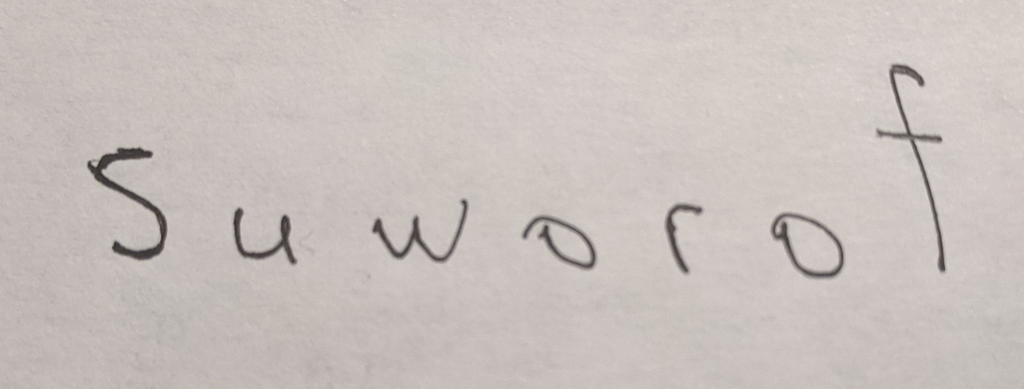

Нужно сжать эту надпись, чтобы высота составила 28 пикселей. Также надо исправить яркость и цвета фото

Получилась такая надпись

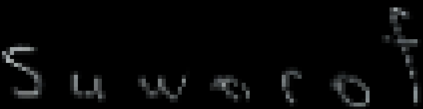

Видно, что ничего не видно. Поэтому я решил подрисовать буквы в местах пробелов

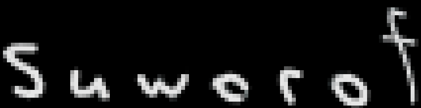

Уже гораздо лучше. Дальше я разбил это на 7 изображений и стал работать с этим. Важно отметить, что изображения надо повернуть влево и отразить по вертикали, т.к. на таких данных мы обучались

```python
written_by_hand = torchvision.datasets.ImageFolder(root = '/content/drive/My Drive/data_science/written_letters/by_hand', transform=transform)
written_by_hand_loader = torch.utils.data.DataLoader(written_by_hand, batch_size=1, shuffle=True)
```

[output not shown]

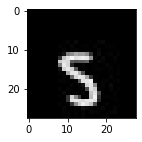

```python
pic = plt.imread('/content/drive/My Drive/data_science/written_letters/by_hand/s/1_S.jpg')
print(pic.shape)

plt.figure(figsize=(2,2))
plt.imshow(np.transpose(pic, axes=(1, 0, 2)))
plt.show()
```

Теперь наши данные похожи на те, на которых мы обучали сеть

```python
with torch.no_grad():
    for data in written_by_hand_loader:
        images, labels = data
        outputs = netConvBN3(images)
        _, prediction = torch.max(outputs.data, 1)
        # т.к. классов новом датасете меньше, то надо немного поработать с лейблами
        print(written_alphabet[labels], alphabet[prediction])
```

```
S D
```

```
O J
U J
W W
F Y
O J
R J
```

Модель ошиблась почти во всех буквах

### В Paint

Эту надпись я затем разбил на 7, каждую размером 28x28

```python
written_by_paint = torchvision.datasets.ImageFolder(root = '/content/drive/My Drive/data_science/written_letters/by_paint', transform=transform)
written_by_paint_loader = torch.utils.data.DataLoader(written_by_paint, batch_size=1, shuffle=True)
```

```python
with torch.no_grad():
    for data in written_by_paint_loader:
        images, labels = data
        outputs = netConvBN3(images)
        _, prediction = torch.max(outputs.data, 1)
        # т.к. классов новом датасете меньше, то надо немного поработать с лейблами
        print(written_alphabet[labels], alphabet[prediction])
```

```
R R
S S
U U
F F
O P
W W
O O
```

Как можно видеть, модель правильно распознала почти все буквы

**Задание 2 (1 балл):**

Используйте transfer learning подход для решения задачи - дообучите какую-либо модель, предобученную на ImageNet, для классификации рукописных букв. Оцените качество решения.  
В качестве предобученой модели можно взять одну из [torchvision models](https://pytorch.org/vision/stable/models.html).

```python
import torch.utils.tensorboard as tensorboard

writer = tensorboard.SummaryWriter('/content/drive/My Drive/data_science/boards/letters')
```

```python
%reload_ext tensorboard
```

```python
class Rotater2:
    def __init__(self):
        pass


    def __call__(self, img: torch.Tensor) -> torch.Tensor:
        img = torch.rot90(img, 1, [1, 2])
        return img
```

```python
data_transform = transforms.Compose([
        transforms.RandomHorizontalFlip(p=1),
        transforms.ToTensor(),
        Rotater2(),
        transforms.Normalize([0.485, 0.456, 0.406], [0.229, 0.224, 0.225])
    ])

trainGnet = torchvision.datasets.ImageFolder(root = '/content/drive/My Drive/data_science/train', transform=data_transform)
valGnet = torchvision.datasets.ImageFolder(root = '/content/drive/My Drive/data_science/test', transform=data_transform)
```

```python
train_dataloader = torch.utils.data.DataLoader(trainGnet, batch_size=4,shuffle=True, num_workers=4)
valid_dataloader = torch.utils.data.DataLoader(valGnet, batch_size=4,shuffle=True, num_workers=4)

class_names = trainGnet.classes
```

```python
device = torch.device("cuda:0" if torch.cuda.is_available() else "cpu")
```

```python
device
```

```
device(type='cpu')
```

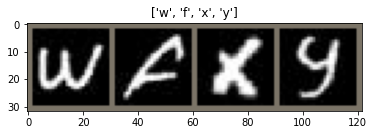

```python
def imshow(inp, title=None):
    """Imshow for Tensor."""
    inp = inp.numpy().transpose((1, 2, 0))
    mean = np.array([0.485, 0.456, 0.406])
    std = np.array([0.229, 0.224, 0.225])
    inp = std * inp + mean
    inp = np.clip(inp, 0, 1)
    plt.imshow(inp)
    if title is not None:
        plt.title(title)
    plt.pause(0.001)  # pause a bit so that plots are updated


# Get a batch of training data
inputs, classes = next(iter(train_dataloader))

# Make a grid from batch
out = torchvision.utils.make_grid(inputs)

imshow(out, title=[class_names[x] for x in classes])
```

Выше - на каких изображениях будет обучаться

Ниже - сырые данные

```
Clipping input data to the valid range for imshow with RGB data ([0..1] for floats or [0..255] for integers).
```

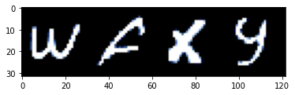

```python
plt.imshow(out.permute(1, 2, 0))
```

```python
import torchvision.models as models

model_ft = models.googlenet(pretrained=True)
num_ftrs = model_ft.fc.in_features

model_ft.fc = nn.Linear(num_ftrs, 26)

model_ft = model_ft.to(device)
```

```
Downloading: "https://download.pytorch.org/models/googlenet-1378be20.pth" to /root/.cache/torch/hub/checkpoints/googlenet-1378be20.pth
```

```python
criterion = nn.CrossEntropyLoss()
optimizer = optim.Adam(model_ft.parameters(), lr=1e-4, betas=(0.99, 0.999), eps=1e-08, weight_decay=0)
```

```python
train_cases = 0
test_cases = 0

for epoch in range(3):  # loop over the dataset multiple times
    train_loss = 0
    train_cases = 0
    valid_loss = 0
    test_cases = 0

    for i, data in enumerate(train_dataloader, 0):
        # get the inputs; data is a list of [inputs, labels]
        inputs, labels = data
        # inputs = inputs.float()
        # labels = labels.long()

        inputs = inputs.to(device)
        labels = labels.to(device)

        # zero the parameter gradients
        optimizer.zero_grad()

        # forward + backward + optimize
        outputs = model_ft(inputs)
        # outputs = outputs.view(-1)

        # forward + backward + optimize
        loss = criterion(outputs, labels)
        loss.backward()
        optimizer.step()

        # print statistics
        train_loss += loss.item()
        train_cases += len(labels.numpy())

        if i % 200 == 199:
            # ...log the running loss
            print('[%d, %5d] loss: %.3f' %
                (epoch + 1, i + 1, train_loss / train_cases))
            writer.add_scalar('training loss',
                             train_loss / train_cases,
                             epoch * len(train_dataloader) + i)
            train_loss = 0.0

    for k, data in enumerate(valid_dataloader, 0):
        with torch.no_grad():
            images, labels = data
            model_ft.eval()
            outputs = model_ft(images)
            # outputs = torch.reshape(outputs, (-1,))

            valid_loss += criterion(outputs, labels)
            test_cases += len(labels.numpy())

            writer.add_scalar('test loss',
                            valid_loss / test_cases,
                            epoch * len(train_dataloader) + k)

print('Finished Training')
```

```
[1,   200] loss: 0.832
[1,   400] loss: 0.398
[1,   600] loss: 0.257
[1,   800] loss: 0.189
[1,  1000] loss: 0.146
[1,  1200] loss: 0.119
[1,  1400] loss: 0.099
[1,  1600] loss: 0.085
[1,  1800] loss: 0.074
[1,  2000] loss: 0.065
[1,  2200] loss: 0.058
[1,  2400] loss: 0.053
[1,  2600] loss: 0.049
[1,  2800] loss: 0.043
[1,  3000] loss: 0.040
```

[output cut: 229 more lines]

```python
# saving gnet
torch.save(model_ft.state_dict(), '/content/drive/My Drive/data_science/gnet.pth')
```

```python
# loading net2
model_ft = models.googlenet(pretrained=True)
num_ftrs = model_ft.fc.in_features
model_ft.fc = nn.Linear(num_ftrs, 26)

model_ft.load_state_dict(torch.load('/content/drive/My Drive/data_science/gnet.pth'))
model_ft.eval()
```

```
GoogLeNet(
  (conv1): BasicConv2d(
    (conv): Conv2d(3, 64, kernel_size=(7, 7), stride=(2, 2), padding=(3, 3), bias=False)
    (bn): BatchNorm2d(64, eps=0.001, momentum=0.1, affine=True, track_running_stats=True)
  )
  (maxpool1): MaxPool2d(kernel_size=3, stride=2, padding=0, dilation=1, ceil_mode=True)
  (conv2): BasicConv2d(
    (conv): Conv2d(64, 64, kernel_size=(1, 1), stride=(1, 1), bias=False)
    (bn): BatchNorm2d(64, eps=0.001, momentum=0.1, affine=True, track_running_stats=True)
  )
  (conv3): BasicConv2d(
    (conv): Conv2d(64, 192, kernel_size=(3, 3), stride=(1, 1), padding=(1, 1), bias=False)
    (bn): BatchNorm2d(192, eps=0.001, momentum=0.1, affine=True, track_running_stats=True)
  )
  (maxpool2): MaxPool2d(kernel_size=3, stride=2, padding=0, dilation=1, ceil_mode=True)
  (inception3a): Inception(
    (branch1): BasicConv2d(
      (conv): Conv2d(192, 64, kernel_size=(1, 1), stride=(1, 1), bias=False)
      (bn): BatchNorm2d(64, eps=0.001, momentum=0.1, affine=True, track_running_stats=True)
    )
    (branch2): Sequential(
      (0): BasicConv2d(
        (conv): Conv2d(192, 96, kernel_size=(1, 1), stride=(1, 1), bias=False)
        (bn): BatchNorm2d(96, eps=0.001, momentum=0.1, affine=True, track_running_stats=True)
      )
      (1): BasicConv2d(
        (conv): Conv2d(96, 128, kernel_size=(3, 3), stride=(1, 1), padding=(1, 1), bias=False)
        (bn): BatchNorm2d(128, eps=0.001, momentum=0.1, affine=True, track_running_stats=True)
      )
    )
    (branch3): Sequential(
      (0): BasicConv2d(
        (conv): Conv2d(192, 16, kernel_size=(1, 1), stride=(1, 1), bias=False)
        (bn): BatchNorm2d(16, eps=0.001, momentum=0.1, affine=True, track_running_stats=True)
      )
      (1): BasicConv2d(
        (conv): Conv2d(16, 32, kernel_size=(3, 3), stride=(1, 1), padding=(1, 1), bias=False)
        (bn): BatchNorm2d(32, eps=0.001, momentum=0.1, affine=True, track_running_stats=True)
      )
    )
```

[output cut: 265 more lines]

```
    )
    (branch4): Sequential(
      (0): MaxPool2d(kernel_size=3, stride=1, padding=1, dilation=1, ceil_mode=True)
      (1): BasicConv2d(
        (conv): Conv2d(832, 128, kernel_size=(1, 1), stride=(1, 1), bias=False)
        (bn): BatchNorm2d(128, eps=0.001, momentum=0.1, affine=True, track_running_stats=True)
      )
    )
  )
  (aux1): None
  (aux2): None
  (avgpool): AdaptiveAvgPool2d(output_size=(1, 1))
  (dropout): Dropout(p=0.2, inplace=False)
  (fc): Linear(in_features=1024, out_features=26, bias=True)
)
```

```python
predictedGnet = np.array([])
targetGnet = np.array([])

with torch.no_grad():
    for i, data in enumerate(valid_dataloader, 0):
        images, labels = data
        outputs = model_ft(images)
        _, prediction = torch.max(outputs.data, 1)

        predictedGnet = np.append(predictedGnet, prediction.data)
        targetGnet = np.append(targetGnet, labels.data)

predictedGnet = torch.tensor(predictedGnet).to(torch.int32)
targetGnet = torch.tensor(targetGnet).to(torch.int32)
```

```python
accuracy = Accuracy()
print('Accuracy: ')
print('gnet:', accuracy(abs(predictedGnet), targetGnet))
print()
```

```
Accuracy:
gnet: tensor(0.9305)
```

Получилась точность 93%. Это самая лучшая модель

**Задание 3 (1 балл):**

Добавьте вывод значений функции потерь и accuracy в tensorboard.  
Метрики нужно выводить и для обучающей, и для тестовой выборки.

```python
%tensorboard --logdir 'drive/My Drive/data_science/boards/letters'
```

```
Reusing TensorBoard on port 6006 (pid 2939), started 0:07:44 ago. (Use '!kill 2939' to kill it.)
```